#Лабораторный практикум ВКИАД c R

**Преподаватель**

```
Дернакова Оксана Владимировна
```

**Студент**

```
Бусько Егор Андреевич, 2 курс, 5 группа, ПМ
```

**Вариант № 3**

### Часть 1. Управление данными в R

Загрузка данных из текстового файла в таблицу данных

```r
qc <- read.table("QC3.txt")
```

Размерность таблицы данных

```r
dim(qc)
```

```
## [1] 100   9
```

Первые три записи из таблицы

```r
head(qc, 3)
```

```
##      V1 V2 V3 V4 V5    V6     V7    V8 V9
## 1 55.48  2  2  1  4 31.18 76.125 4.565  5
## 2 60.70  2  3  1  4 31.88 82.050 4.555  5
## 3 65.12  5  1  1  4 30.96 86.490 5.765  3
```

Таблица после переименования переменных

```r
names(qc) <- c('c1','kit','nbug','maker','vendor','c2','c3','c4','bug')
head(qc)
```

```
##      c1 kit nbug maker vendor    c2     c3    c4 bug
## 1 55.48   2    2     1      4 31.18 76.125 4.565   5
## 2 60.70   2    3     1      4 31.88 82.050 4.555   5
## 3 65.12   5    1     1      4 30.96 86.490 5.765   3
## 4 62.61   1    1     1      3 30.42 84.645 4.725   5
## 5 59.20   6    2     2      3 32.76 79.035 4.200   3
## 6 62.25   2    5     1      2 32.56 82.890 5.365  10
```

Комплексная статистика по переменной vendor

```r
summary(qc$vendor)
```

```
##    Min. 1st Qu.  Median    Mean 3rd Qu.    Max.
##    1.00    2.00    3.00    2.87    4.00    4.00
```

Комплексная статистика по переменной vendor после ее преобразования в переменную-фактор

```r
vendor <- as.factor(qc[,5])
summary(vendor)
```

```
##  1  2  3  4
## 14 23 25 38
```

Число изделий, у которых количество некритических дефектов больше 3

```r
sum(qc $ nbug > 3)
```

```
## [1] 14
```

Наблюдения, для которых количество некритических дефектов равно максимальному

```r
for(k in 1:100){
  if(qc[k,3]==max(qc$nbug)){
    print(qc[k,])
  }
}
```

```
##       c1 kit nbug maker vendor    c2    c3   c4 bug
## 93 59.59   5    7     2      4 37.35 79.71 4.56  11
```

### Часть 2. Описательная статистика и графический анализ

Присоединение таблицы данных к списку текущих переменных и загрузка дополнительной библиотеки

```r
attach(qc)
library("e1071")
```

Выборочные среднее и медиана для переменной с1 в указанном порядке

```r
mean(c1)
```

```
## [1] 60.7433
```

```r
median(c1)
```

```
## [1] 60.97
```

Выборочные квартили Q1,Q2,Q3, а также интерквартильный размах для переменной c1

```r
quantile(c1, probs = c(25,50,75)/100)
```

```
##    25%    50%    75%
## 59.430 60.970 62.285
```

```r
IQR(c1)
```

```
## [1] 2.855
```

Комплексная статистика по переменной c1

```r
summary(c1)
```

```
##    Min. 1st Qu.  Median    Mean 3rd Qu.    Max.
##   55.13   59.43   60.97   60.74   62.28   65.74
```

Дисперсия для переменной с1 и переменной 2 * с1 + 100

```r
var(c1)
```

```
## [1] 5.449228
```

```r
var(2 * c1 + 100)
```

```
## [1] 21.79691
```

**Вывод:** Вторая дисперсия больше в 4 раза

Дисперсия для переменной с1, полученная с помощью векторного выражения

```r
sum((c1-mean(c1))^2)/(length(c1)-1)
```

```
## [1] 5.449228
```

Гистограмма для переменной с1

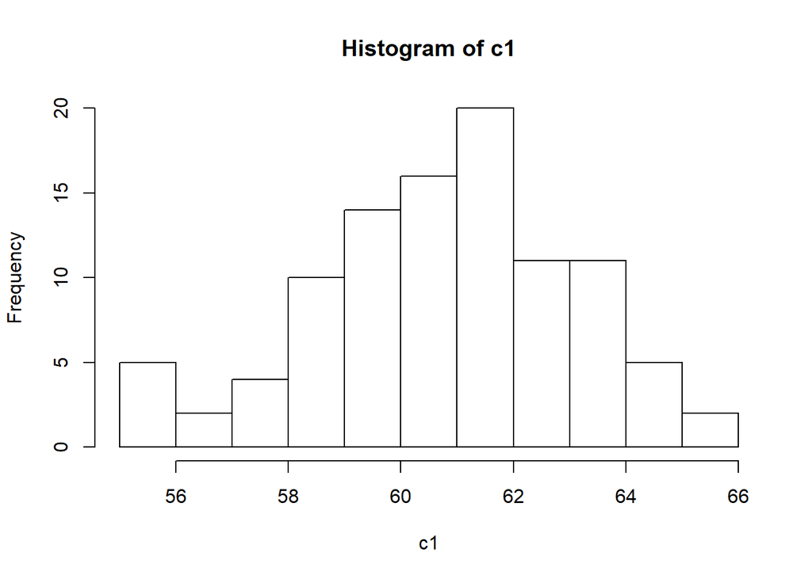

```r
hist(c1)
```

Асимметрия и эксцесс для переменной c1 в указанном порядке

```r
skewness(c1)
```

```
## [1] -0.3448012
```

```r
kurtosis(c1)
```

```
## [1] -0.2856225
```

Проверка распределения переменной c1 на нормальность с помощью статистического теста Лиллиефорса

```r
library(nortest)

lillie.test(c1)
```

```
##
##  Lilliefors (Kolmogorov-Smirnov) normality test
##
## data:  c1
## D = 0.060892, p-value = 0.4807
```

**Вывод:** Гипотеза о нормальном распределении принимается на уровне значимости 0.05.

### Часть 3. Анализ статистических зависимостей

Перекодирование переменной kit в переменную с двумя значениями (1 и 2)

```r
kit = data.frame(kit = ifelse(kit < 3, kit<-1, kit<-2))
```

Ранговый коэффициент корреляции Спирмена для переменных kit и maker

```r
cor(kit, maker, method = "spearman")
```

```
##           [,1]
## kit 0.09929932
```

Таблица сопряженности для переменных kit и maker

```r
dat<-data.frame(kit, maker)
with(dat,table(kit, maker, dnn = c("kit", "maker")))
```

```
##    maker
## kit  1  2
##   1 29 22
##   2 23 26
```

Вывод: Согласно ранговому коэффициенту корреляции и таблице сопряженности согласованность между переменными практически отсутствует.

Тест на равенство нулю коэффициента корреляции для переменных с1 и с3

```r
cor.test(c1,c3)
```

```
##
##  Pearson's product-moment correlation
##
## data:  c1 and c3
## t = 17.898, df = 98, p-value < 2.2e-16
## alternative hypothesis: true correlation is not equal to 0
## 95 percent confidence interval:
##  0.8195065 0.9143318
## sample estimates:
##       cor
## 0.8750684
```

Вывод: Гипотеза о равенстве нулю коэффициента корреляции между переменными отклоняется на уровне значимости 0.05.

Корреляционная матрица для числовых характеристик с1-c4.

```r
d <- data.frame(qc[1],qc[6],qc[7],qc[8])
cor(d)
```

```
##             c1           c2          c3           c4
## c1  1.00000000 -0.010034222 0.875068389  0.583419330
## c2 -0.01003422  1.000000000 0.003347985 -0.009795793
## c3  0.87506839  0.003347985 1.000000000  0.539350201
## c4  0.58341933 -0.009795793 0.539350201  1.000000000
```

Матрица корреляции в удобном представлении

```r
symnum(cor(d))
```

```
##    c1 c2 c3 c4
## c1 1
## c2    1
## c3 +     1
## c4 .     .  1
## attr(,"legend")
## [1] 0 ' ' 0.3 '.' 0.6 ',' 0.8 '+' 0.9 '*' 0.95 'B' 1
```

Вывод: Наибольший коэффициент корреляции наблюдается между переменными c1 и c3.

Построение регрессионной модели по переменным c1 (зависимая - отклик) и c3 (независимая - фактор) и вывод общей статистики по результатам оценивания

```r
linmod<-lm(c1 ~ c3)
summary(linmod)
```

```
##
## Call:
## lm(formula = c1 ~ c3)
##
## Residuals:
##     Min      1Q  Median      3Q     Max
## -3.2475 -0.6271  0.0256  0.6880  2.7174
##
## Coefficients:
##             Estimate Std. Error t value Pr(>|t|)
## (Intercept)  0.26383    3.38098   0.078    0.938
## c3           0.73699    0.04118  17.898   <2e-16 ***
## ---
## Signif. codes:  0 '***' 0.001 '**' 0.01 '*' 0.05 '.' 0.1 ' ' 1
##
## Residual standard error: 1.136 on 98 degrees of freedom
## Multiple R-squared:  0.7657, Adjusted R-squared:  0.7634
## F-statistic: 320.3 on 1 and 98 DF,  p-value: < 2.2e-16
```

Диаграмма рассеяния с линией регрессии для переменных c1 и c3

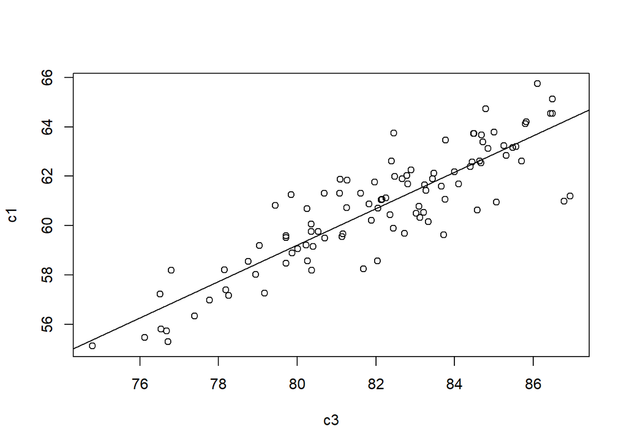

```r
plot(c3,c1)
abline(linmod)
```

Коэффициенты регрессионной модели

```r
coefficients(linmod)
```

```
## (Intercept)          c3
##   0.2638329   0.7369932
```

График “Квантиль-квантиль” для остатков модели

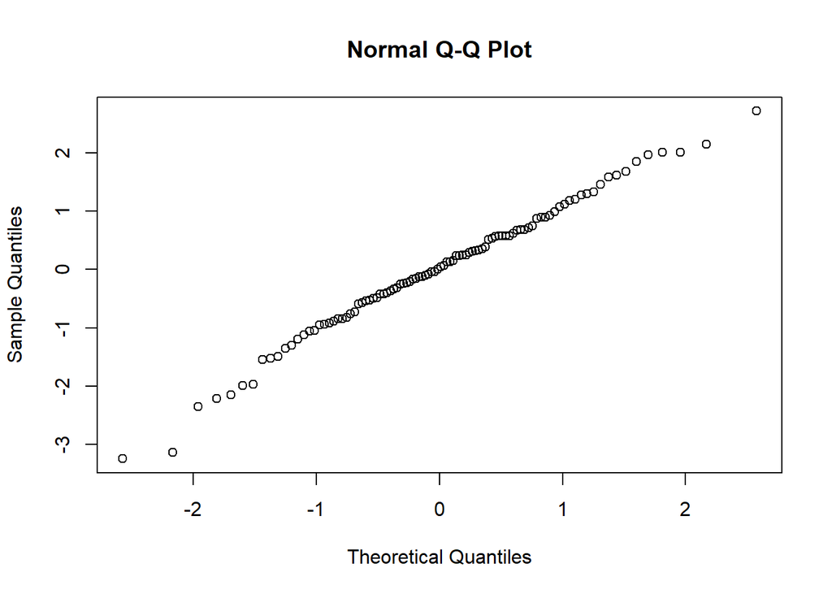

```r
res <- residuals(linmod)
qqnorm(res)
```

Вывод: Большинство точек располагаются вблизи прямой линии, поэтому распределение остатков близко к нормальному.

Тест Колмогорова-Смирнова на нормальность остатков

```r
ks.test(res,"pnorm")
```

```
##
##  One-sample Kolmogorov-Smirnov test
##
## data:  res
## D = 0.045718, p-value = 0.985
## alternative hypothesis: two-sided
```

Вывод: Критерий принимает гипотезу о нормальном распределении остатков на уровне значимости 0.05.

### Часть 4. Анализ неоднородных данных

Частоты значений для переменной maker

```r
table(maker)
```

```
## maker
##  1  2
## 52 48
```

Двухвыборочный t-критерий по переменной, для которой наблюдается значимое различие средних в двух подвыборках (по значениям переменной maker), c разбиением на подвыборки по переменной maker

```r
t.test(c2~maker)
```

```
##
##  Welch Two Sample t-test
##
## data:  c2 by maker
## t = -8.5391, df = 94.451, p-value = 2.26e-13
## alternative hypothesis: true difference in means is not equal to 0
## 95 percent confidence interval:
##  -2.738593 -1.705349
## sample estimates:
## mean in group 1 mean in group 2
##        32.01115        34.23313
```

Вывод: Гипотеза о равенстве средних в двух подвыборках отклоняется на уровне значимости 0.05 для переменной c2 (средние значения характеристики c2 у двух производителей статистически различимы).

“Ящики с усами” для переменной c2 в разрезе по номеру производителя

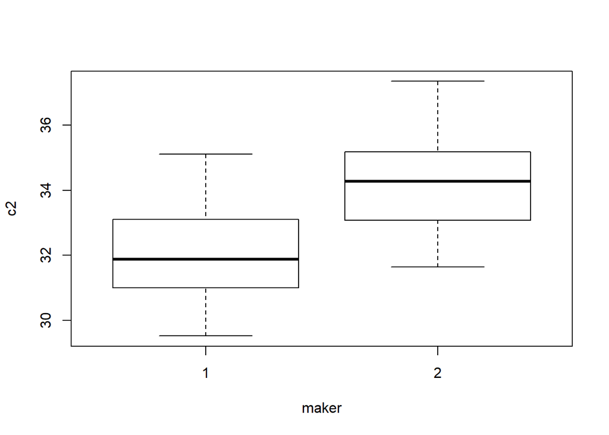

```r
boxplot(c2~maker)
```

График ядерной оценки плотности распределения для переменной c2

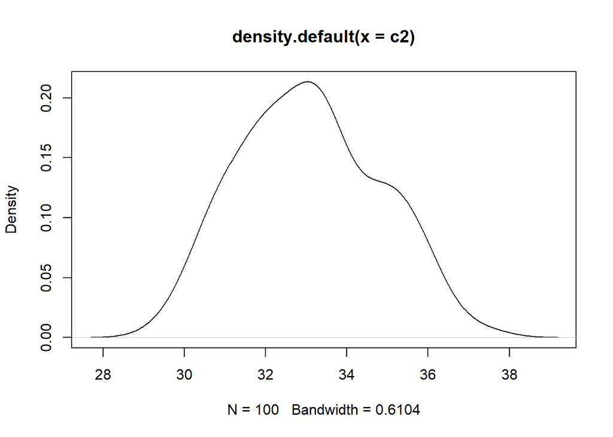

```r
plot(density.default(c2))
```

Вывод: Из графика видно, что выборка описывается моделью, которая представляет собой смесь двух распределений.

### Часть 5. Классификация неоднородных данных

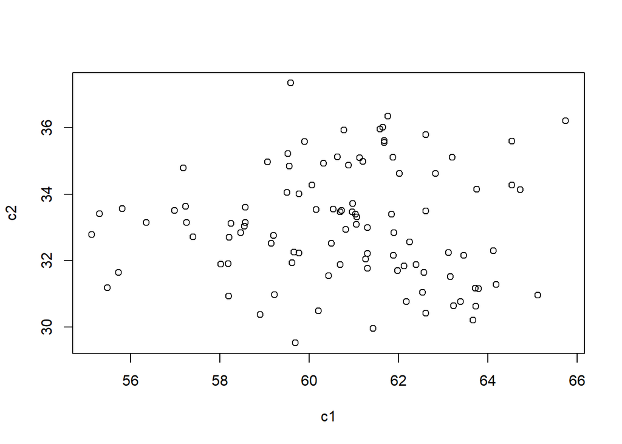

```r
plot(c1,c2)
```

Первые 3 строки матрицы из переменных c1 и c2

```r
binded<-cbind(c1,c2)
head(binded,3)
```

```
##         c1    c2
## [1,] 55.48 31.18
## [2,] 60.70 31.88
## [3,] 65.12 30.96
```

Применение кластерного анализа и вывод частот наблюдений в каждом оцененном классе

```r
kmres<-kmeans(binded,2)
table(kmres[1])
```

```
##
##  1  2
## 62 38
```

График с классовой принадлежностью наблюдений

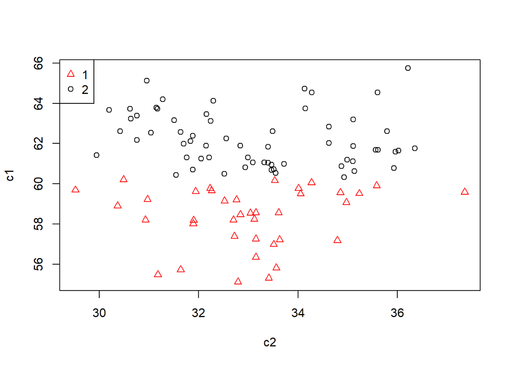

```r
plot(c1~c2, pch =ifelse(kmres$cluster == 1,1,2), col = ifelse(kmres$cluster == "1","1","2"))
legend("topleft", legend=c("1", "2"), pch = c(2,1), col = c ("red","black"))
```

Работа с данными закончена

```r
detach(qc)
```